[figure not shown]

LU(w/o STI)-2

General Description

LUBRICATION

1. General Description

A: SPECIFICATION

Lubrication method Forced lubrication

Oil pump

Pump type Trochoid type

Number of teeth

Inner rotor 11

Outer rotor 12

Outer rotor diameter × Thickness mm (in) 77 × 14 (3.03 × 0.55)

Performance

(Oil temperature 120°C

(248°F))

600 rpm

Discharge

pressure

kPa (kg/cm

2

, psi) 35 (0.4, 5.1)

Discharge

rate

L (US qt, Imp qt)/min 7.4 (7.8, 6.5) or more

6,700 rpm

Discharge

pressure

kPa (kg/cm

2

, psi) 321 (3.3, 46.6)

Discharge

rate

L (US qt, Imp qt)/min 60.2 (63.6, 53.0) or more

Relief valve working pressure kPa (kg/cm

2

, psi) 700 (7.1, 102)

Oil filter

Filter type Full-flow filter type

Filtration area cm

2

(sq in)

Outer diameter: 80 mm (3.15 in)

(black)

900 (139.5)

Outer diameter: 67.4 mm (2.65 in)

(blue)

867 (134.3)

By-pass valve opening pressure kPa (kg/cm

2

, psi) 160 (1.6, 23.2)

Outer diameter × Width mm (in)

Outer diameter: 80 mm (3.15 in)

(black)

80 × 65 (3.15 × 2.55)

Outer diameter: 67.4 mm (2.65 in)

(blue)

67.4 × 87.1 (2.65 × 3.43)

Installation screw specifications M 20 × 1.5

Oil pressure

switch

Type Immersed contact point type

Operating voltage 12 V

Warning light operating pressure kPa (kg/cm

2

, psi) 14.7 (0.1, 2.1)

Proof pressure kPa (kg/cm

2

, psi) 981 (10, 142.2)

Engine oil

Total capacity (at overhaul) L (US qt, Imp qt) 6.0 (6.3, 5.3)

When replacing engine oil and oil filter L (US qt, Imp qt) 5.1 (5.4, 4.5)

When replacing engine oil only L (US qt, Imp qt) 4.9 (5.2, 4.3)

[figure not shown]

LU(w/o STI)-3

General Description

LUBRICATION

Specified oil:

CAUTION:

• Use 5W-30 (synthetic oil).

• It is acceptable to fill an engine with oil of another brand when replacing the oil, but make sure to

use the following engine oil specified by Subaru.

NOTE:

The proper viscosity oil helps the engine maintain its ideal temperature, and cranking speed increased by re-

ducing viscosity friction in hot condition.

Engine oil standard SAE viscosity No.

Those with the API standard SN

“Resource Conserving” or SM

“Energy Conserving” logo.

or

Those with the ILSAC standard GF-4

or GF-5 “starburst mark” displayed on

top of the container.

5W-30 (synthetic oil)

RM-00081

FOR

GASOLINE

ENGINES

RM-00002

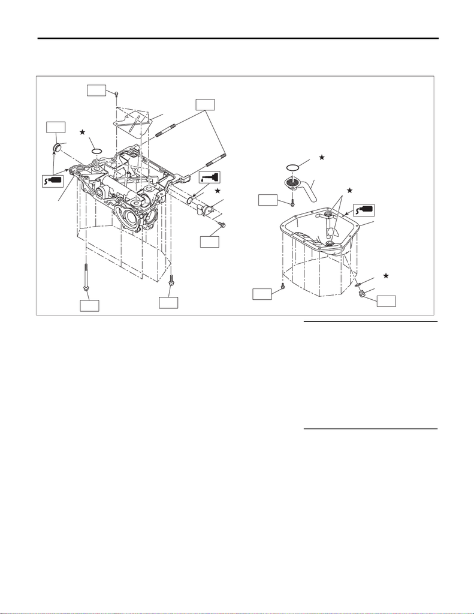

LU(w/o STI)-4

General Description

LUBRICATION

B: COMPONENT

1. OIL PAN AND STRAINER

(1) Oil pan upper (7) Oil pan seal ring Tightening torque: N·m (kgf-m, ft-lb)

(2) O-ring (8) Drain plug gasket T1: 6.4 (0.7, 4.7)

(3) Baffle plate (9) Drain plug T2: 10 (1.0, 7.4)

(4) O-ring (10) Oil level switch T3: 41.7 (4.3, 30.8)

(5) Oil strainer (11) O-ring T4: 90 (9.2, 66.4)

(6) Oil pan (12) Plug T5: <Ref. to LU(w/o STI)-21, OIL

PAN AND STRAINER, INSTAL-

LATION, Oil Pan and Strainer.>

T6: <Ref. to LU(w/o STI)-27, OIL

PAN UPPER, INSTALLATION,

Oil Pan and Strainer.>

LU-03223

T6

T1

T2

(2)

(3)

(11)

T1

(10)

(1)

T3

T5

T1

(4)

(5)

(6)

(7)

(8)

(9)

T4

(12)

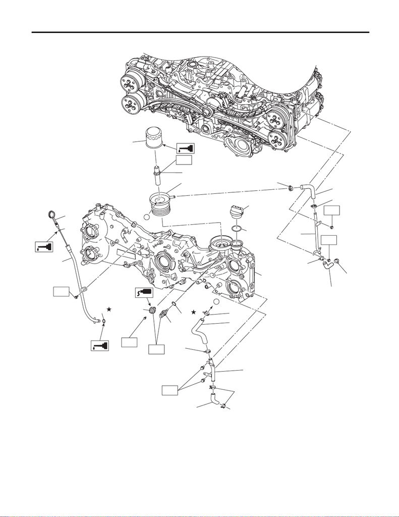

LU(w/o STI)-5

General Description

LUBRICATION

2. OIL FILTER AND OIL LEVEL GAUGE

LU-03189

(5)

(6)

(7)

(10)

(4)

(3)

(11)

T3

(12)

(15)

(14)

(16)

T2

(2)

T4

(13)

(1)

A

T2

T2

(17)

(17)

(17)

(20)

(19)

(18)

(17)

(8)

(17)

(17)

(17)

(9)

A

[figure not shown]

LU(w/o STI)-6

General Description

LUBRICATION

C: CAUTION

• Prior to starting work, pay special attention to the following:

1. Always wear work clothes, a work cap, and protective shoes. Additionally, wear a helmet, protective

goggles, etc. if necessary.

2. Protect the vehicle using a seat cover, fender cover, etc.

3. Prepare the service tools, clean cloth, containers to catch grease and oil, etc.

• Prepare a container and cloth when performing work which oil possibly spills. If oil spills, wipe it off imme-

diately to prevent from penetrating into floor or flowing out for environmental protection.

• Vehicle components are extremely hot immediately after driving. Be wary of receiving burns from heated

parts.

• When performing a repair, identify the cause of trouble and avoid unnecessary removal, disassembly and

replacement.

• Before disconnecting connectors of sensors or units, be sure to disconnect the ground cable from battery.

• Always use the jack-up point when the shop jacks or rigid racks are used to support the vehicle.

• Remove contamination including dirt and corrosion before removal, installation, disassembly or assembly.

• Keep the removed parts in order and protect them from dust and dirt.

• All removed parts, if to be reused, should be reinstalled in the original positions with attention to the correct

directions, etc.

• Bolts, nuts and washers should be replaced with new parts as required.

• Be sure to tighten the fasteners including bolts and nuts to the specified torque.

• If the engine oil is spilt over exhaust pipe or the under cover, wipe it off with cloth to avoid emitting smoke

or causing a fire.

• Follow all government and local regulations concerning disposal of refuse when disposing of oil.

(1) Oil filter (10) O-ring (19) Side engine oil cooler hose A

(2) Oil cooler connector (11) O-ring (20) Side engine oil cooler hose B

(3) Oil filler cap (12) Gasket

(4) Chain cover (13) Oil cooler Tightening torque: N·m (kgf-m, ft-lb)

(5) Oil level gauge (14) Front engine oil cooler pipe T1: 1.5 (0.2, 1.1)

(6) O-ring (15) Front engine oil cooler hose A T2: 6.4 (0.7, 4.7)

(7) Oil level gauge guide (16) Front engine oil cooler hose B T3: 18 (1.8, 13.3)

(8) Oil pressure switch (17) Clip T4: 45 (4.6, 33.2)

(9) Engine oil temperature sensor (18) Side engine oil cooler pipe

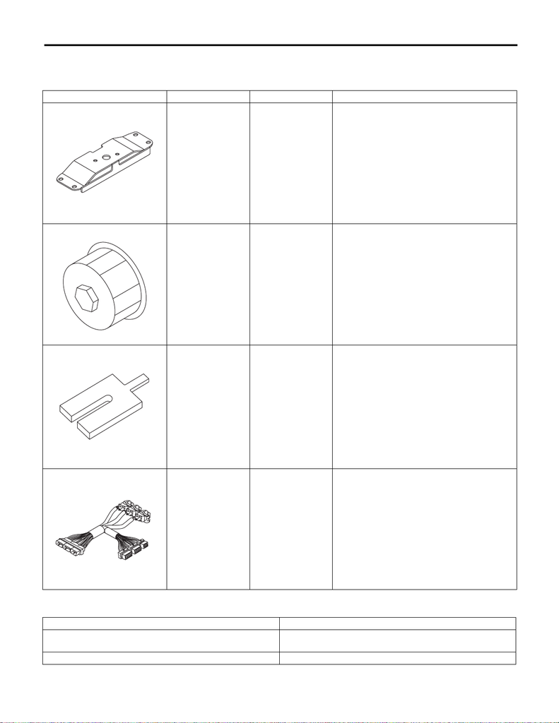

LU(w/o STI)-7

General Description

LUBRICATION

D: PREPARATION TOOL

1. SPECIAL TOOL

2. GENERAL TOOL

ILLUSTRATION TOOL NUMBER DESCRIPTION REMARKS

41099YC001

(Newly adopted tool)

ST REAR MOUNT Used for removing and installing oil level switch.

(CVT model)

498547000 OIL FILTER

WRENCH

Used for removing and installing oil filter (black).

(Outer diameter: 80 mm (3.15 in))

18632AA030

(Newly adopted tool)

STAND ASSY Used for removing and installing oil pan.

18460AA030 CHECK BOARD Used for inspecting the oil level switch.

TOOL NAME REMARKS

Oil filter wrench (65/67 mm 14 Flutes) Used for removing and installing oil filter (blue). (Outer diame-

ter: 67.4 mm (2.65 in))

Circuit tester Used for measuring resistance and voltage.

ST41099YC001

ST-498547000

ST18632AA030

ST18460AA030